# Portfolio_Healthcare.EDA

Health Care Data Analysis

**Author: YANG GUAN JIAN GUO**

Data Summary

First we read in the data.

```python
import pandas as pd
import matplotlib.pyplot as plt
import seaborn as sns
import numpy as np
```

```python
health = pd.read_csv("healthcare_dataset.csv")
```

In practice, it is best to first get an idea of the size of the dataset. The main things to know are the number of observations, which correspond to the number of participants, and the number of variables representing the properties of each data point we are interested in.

```python
num_observations, num_variables = health.shape[0],health.shape[1]
print("Size of the Dataset - Observations: {}, Variables: {}".format(num_observations, num_variables))
```

```
Size of the Dataset - Observations: 55500, Variables: 15
```

The number of variables is 15, which is a reasonable size for us to examine the dataset directly. We will first look at the first 5 and last 5 observations to get a rough idea of the dataset. Then, we will create a short summary of each variable using the .info() function.

```python
health.head()
```

|  | Name | Age | Gender | Blood Type | Medical Condition | Date of Admission | Doctor | Hospital | Insurance Provider | Billing Amount | Room Number | Admission Type | Discharge Date | Medication | Test Results |
| --- | --- | --- | --- | --- | --- | --- | --- | --- | --- | --- | --- | --- | --- | --- | --- |
| 0 | Bobby JacksOn | 30 | Male | B- | Cancer | 2024-01-31 | Matthew Smith | Sons and Miller | Blue Cross | 18856.281306 | 328 | Urgent | 2024-02-02 | Paracetamol | Normal |
| 1 | LesLie TErRy | 62 | Male | A+ | Obesity | 2019-08-20 | Samantha Davies | Kim Inc | Medicare | 33643.327287 | 265 | Emergency | 2019-08-26 | Ibuprofen | Inconclusive |
| 2 | DaNnY sMitH | 76 | Female | A- | Obesity | 2022-09-22 | Tiffany Mitchell | Cook PLC | Aetna | 27955.096079 | 205 | Emergency | 2022-10-07 | Aspirin | Normal |
| 3 | andrEw waTtS | 28 | Female | O+ | Diabetes | 2020-11-18 | Kevin Wells | Hernandez Rogers and Vang, | Medicare | 37909.782410 | 450 | Elective | 2020-12-18 | Ibuprofen | Abnormal |
| 4 | adrIENNE bEll | 43 | Female | AB+ | Cancer | 2022-09-19 | Kathleen Hanna | White-White | Aetna | 14238.317814 | 458 | Urgent | 2022-10-09 | Penicillin | Abnormal |

```python
health.tail()
```

|  | Name | Age | Gender | Blood Type | Medical Condition | Date of Admission | Doctor | Hospital | Insurance Provider | Billing Amount | Room Number | Admission Type | Discharge Date | Medication | Test Results |
| --- | --- | --- | --- | --- | --- | --- | --- | --- | --- | --- | --- | --- | --- | --- | --- |
| 55495 | eLIZABeTH jaCkSOn | 42 | Female | O+ | Asthma | 2020-08-16 | Joshua Jarvis | Jones-Thompson | Blue Cross | 2650.714952 | 417 | Elective | 2020-09-15 | Penicillin | Abnormal |
| 55496 | KYle pEREz | 61 | Female | AB- | Obesity | 2020-01-23 | Taylor Sullivan | Tucker-Moyer | Cigna | 31457.797307 | 316 | Elective | 2020-02-01 | Aspirin | Normal |
| 55497 | HEATher WaNG | 38 | Female | B+ | Hypertension | 2020-07-13 | Joe Jacobs DVM | and Mahoney Johnson Vasquez, | UnitedHealthcare | 27620.764717 | 347 | Urgent | 2020-08-10 | Ibuprofen | Abnormal |
| 55498 | JENniFER JOneS | 43 | Male | O- | Arthritis | 2019-05-25 | Kimberly Curry | Jackson Todd and Castro, | Medicare | 32451.092358 | 321 | Elective | 2019-05-31 | Ibuprofen | Abnormal |
| 55499 | jAMES GARCiA | 53 | Female | O+ | Arthritis | 2024-04-02 | Dennis Warren | Henry Sons and | Aetna | 4010.134172 | 448 | Urgent | 2024-04-29 | Ibuprofen | Abnormal |

```python
health.info()
```

```
<class 'pandas.core.frame.DataFrame'>
RangeIndex: 55500 entries, 0 to 55499
Data columns (total 15 columns):
 #   Column              Non-Null Count  Dtype
---  ------              --------------  -----
 0   Name                55500 non-null  object
 1   Age                 55500 non-null  int64
 2   Gender              55500 non-null  object
 3   Blood Type          55500 non-null  object
 4   Medical Condition   55500 non-null  object
 5   Date of Admission   55500 non-null  object
 6   Doctor              55500 non-null  object
 7   Hospital            55500 non-null  object
 8   Insurance Provider  55500 non-null  object
 9   Billing Amount      55500 non-null  float64
 10  Room Number         55500 non-null  int64
 11  Admission Type      55500 non-null  object
 12  Discharge Date      55500 non-null  object
 13  Medication          55500 non-null  object
 14  Test Results        55500 non-null  object
dtypes: float64(1), int64(2), object(12)
memory usage: 6.4+ MB
```

We have enough information based on the dataset to give a description of each variables.

### Detailed Description of Variables

| Variable Name | Description |
| --- | --- |
| Name | Patient's name in mixed case format, representing their full name |
| Age | Age of the patient in years |
| Gender | Gender of the patient (Male, Female) |
| Blood Type | Blood type of the patient (e.g., A+, B-, AB+) |
| Medical Condition | Medical condition or diagnosis of the patient (e.g., Cancer, Obesity, Diabetes) |
| Date of Admission | Date when the patient was admitted to the hospital (YYYY-MM-DD) |
| Doctor | Name of the doctor responsible for the patient's treatment |
| Hospital | Name of the hospital where the patient was admitted |
| Insurance Provider | Insurance provider covering the patient |
| Billing Amount | Amount billed for the patient's treatment (in USD) |
| Room Number | Room number where the patient stayed during treatment |
| Admission Type | Type of admission (e.g., Urgent, Emergency, Elective) |
| Discharge Date | Date when the patient was discharged from the hospital (YYYY-MM-DD) |
| Medication | Medications prescribed to the patient during their treatment |
| Test Results | Results of medical tests conducted on the patient |

There are no missing values in our dataset based on the summary from .info(), which is quite nice because it means we do not have to deal with filling in any gaps.

A curious detail in this dataset is that the patient names appear to be a mixture of uppercase and lowercase without any discernible patterns. It is recommended that we perform some data cleaning by converting all names to lowercase (based on the author's preference) for readability.

```python
health['Name'] = health['Name'].str.lower()
health['Name'].head()
```

```
0    bobby jackson
1     leslie terry
2      danny smith
3     andrew watts
4    adrienne bell
Name: Name, dtype: object
```

Exploratory Data Analysis - Data Visualization

Exploratory Data Analysis (EDA) involves examining and understanding the dataset to uncover patterns, anomalies, and relationships. We will begin by first examine the numerical variables "Age" and "Billing Amount" as to provide a more precise description of the variables.

```python
health[['Age','Billing Amount']].describe()
```

|  | Age | Billing Amount |
| --- | --- | --- |
| count | 55500.000000 | 55500.000000 |
| mean | 51.539459 | 25539.316097 |
| std | 19.602454 | 14211.454431 |
| min | 13.000000 | -2008.492140 |
| 25% | 35.000000 | 13241.224652 |
| 50% | 52.000000 | 25538.069376 |
| 75% | 68.000000 | 37820.508436 |
| max | 89.000000 | 52764.276736 |

Billing Amount: The billing amounts vary widely, ranging from negative values to a maximum of $52,764.28. The negative values suggest possible credits or refunds in billing. The median billing amount is $25,538.07, with a noticeable spread in values as indicated by the standard deviation.

Negative Billing Amounts: The presence of negative billing amounts suggests cases where credits or adjustments have been made to the patient's bills, possibly due to refunds or overpayments.

We can also provide appropriate plots of the variables 'Age' and 'Billing Amount' to visualize the dataset using histograms and box-plots.

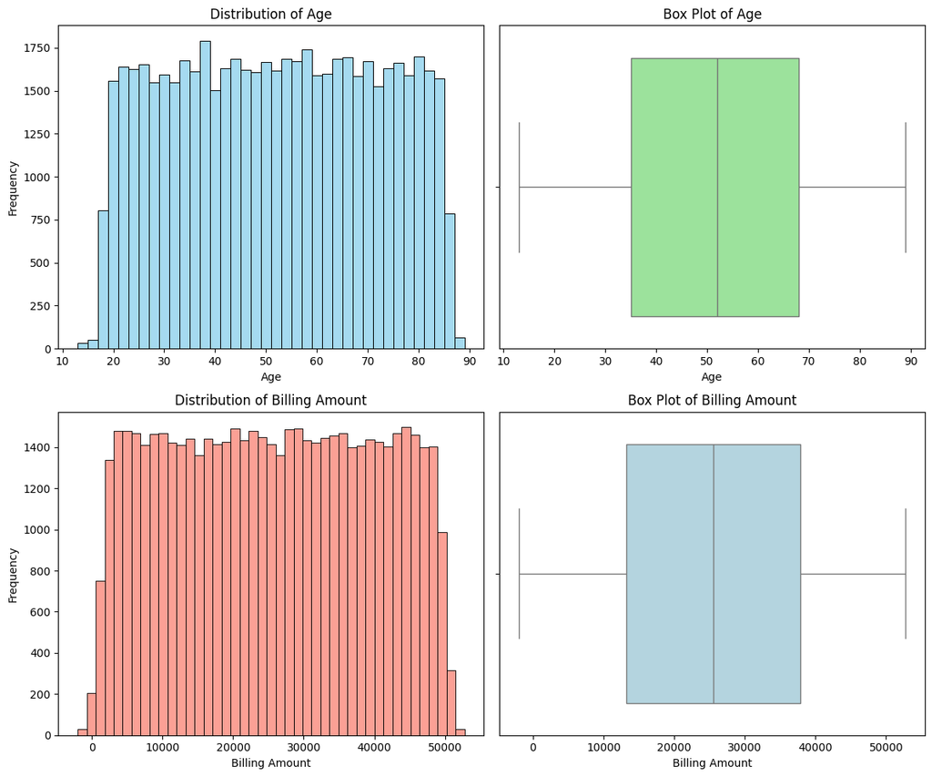

```python
fig, axes = plt.subplots(nrows=2, ncols=2, figsize=(12, 10))

# Plot histograms for Age
bin_edges = np.arange(13, 90, 2)
sns.histplot(health['Age'], ax=axes[0, 0], kde=False, color='skyblue', edgecolor='black', bins=bin_edges)
axes[0, 0].set_title('Distribution of Age')
axes[0, 0].set_xlabel('Age')
axes[0, 0].set_ylabel('Frequency')

# Plot box plot for Age
sns.boxplot(x=health['Age'], ax=axes[0, 1], color='lightgreen')
axes[0, 1].set_title('Box Plot of Age')
axes[0, 1].set_xlabel('Age')

# Plot histograms for Billing Amount
sns.histplot(health['Billing Amount'], ax=axes[1, 0], kde=False, color='salmon', edgecolor='black')
axes[1, 0].set_title('Distribution of Billing Amount')
axes[1, 0].set_xlabel('Billing Amount')
axes[1, 0].set_ylabel('Frequency')

# Plot box plot for Billing Amount
sns.boxplot(x=health['Billing Amount'], ax=axes[1, 1], color='lightblue')
axes[1, 1].set_title('Box Plot of Billing Amount')
axes[1, 1].set_xlabel('Billing Amount')

# Adjust layout
plt.tight_layout()

# Display the plots
plt.show()
```

The histograms for both 'Age' and 'Billing Amount' display distributions that appear close to uniform and nearly symmetrical. The age distribution shows a relatively even spread across the range, suggesting a broad representation of different age groups. Similarly, the billing amount distribution exhibits a balanced distribution of costs, indicating consistent expenditure patterns across observations. These symmetrical distributions imply that the data points are evenly distributed without significant skewness, highlighting a balanced dataset in terms of these variables.

Next, let's delve into the 'Date of Admission' and 'Discharge Date' to gain a better understanding of the temporal aspects of the data. Firstly, we will convert these variables into a standard datetime format that computers can process consistently. Following this, summarizing the date data with statistics such as minimum, maximum, and average values provides a clear overview of when patients enter and leave the hospital. These summaries reveal insights into patterns of hospital utilization, highlighting busy periods and quieter times, which are crucial for resource planning and operational management.

```python
health['Date of Admission'] = pd.to_datetime(health['Date of Admission'])
health['Discharge Date'] = pd.to_datetime(health['Discharge Date'])
```

```python
health[['Date of Admission','Discharge Date']].describe()
```

|  | Date of Admission | Discharge Date |
| --- | --- | --- |
| count | 55500 | 55500 |
| mean | 2021-11-01 01:02:22.443243008 | 2021-11-16 13:15:20.821621504 |
| min | 2019-05-08 00:00:00 | 2019-05-09 00:00:00 |
| 25% | 2020-07-28 00:00:00 | 2020-08-12 00:00:00 |
| 50% | 2021-11-01 00:00:00 | 2021-11-17 00:00:00 |
| 75% | 2023-02-03 00:00:00 | 2023-02-18 00:00:00 |
| max | 2024-05-07 00:00:00 | 2024-06-06 00:00:00 |

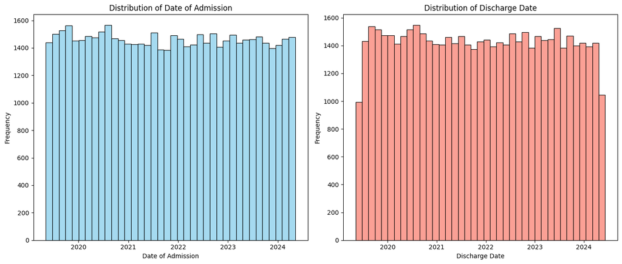

```python
fig, axes = plt.subplots(nrows=1, ncols=2, figsize=(14, 6))

# Plot histograms for Age

sns.histplot(health['Date of Admission'], ax=axes[0], color='skyblue', edgecolor='black')
axes[0].set_title('Distribution of Date of Admission')
axes[0].set_xlabel('Date of Admission')
axes[0].set_ylabel('Frequency')



# Plot histograms for Billing Amount
sns.histplot(health['Discharge Date'], ax=axes[1] , color='salmon', edgecolor='black')
axes[1].set_title('Distribution of Discharge Date')
axes[1].set_xlabel('Discharge Date')
axes[1].set_ylabel('Frequency')


# Adjust layout
plt.tight_layout()

# Display the plots
plt.show()
```

The histograms for 'Date of Admission' and 'Discharge Date' show a uniform distribution without noticeable seasonal trends. This suggests consistent patient admissions and discharges throughout the observed period, indicating stable demand for hospital services. This steady flow is valuable for healthcare resource planning and operational management, reflecting well-managed patient care and consistent healthcare needs within the dataset. Understanding these temporal patterns is essential for optimizing hospital operations year-round.

Next, we will analyze the duration of hospital stays, which will provides valuable insights into patient care efficiency and resource utilization.

```python
# Calculate duration of admission (length of stay in days)
health['Duration of Admission'] = (health['Discharge Date'] - health['Date of Admission']).dt.days

# Display the summary of the new variable duration of admission
health['Duration of Admission'].describe()
```

```
count    55500.000000
mean        15.509009
std          8.659600
min          1.000000
25%          8.000000
50%         15.000000
75%         23.000000
max         30.000000
Name: Duration of Admission, dtype: float64
```

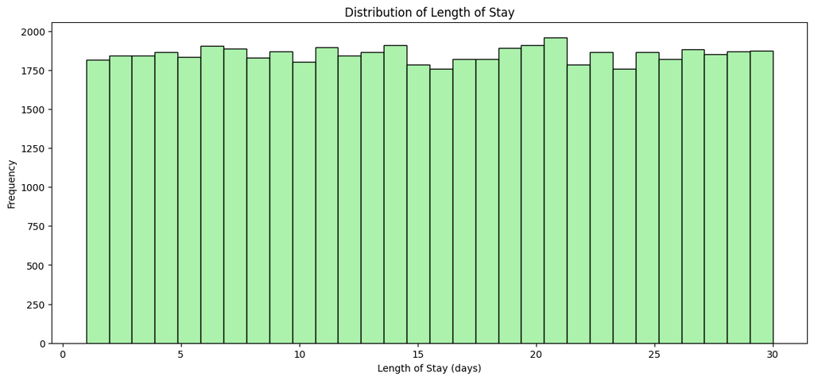

```python
plt.figure(figsize=(14, 6))
sns.histplot(health['Duration of Admission'] , color='lightgreen',bins = 30)
plt.title('Distribution of Length of Stay')
plt.xlabel('Length of Stay (days)')
plt.ylabel('Frequency')
plt.show()
```

The histogram displaying the distribution of the 'Duration of Admission' variable reveals a uniform pattern. This uniformity indicates that across the dataset, patients generally have consistent lengths of stay in the hospital, with no significant peaks or valleys in the distribution. The mean duration of approximately 15.5 days suggests a typical length of hospital stay, while the range from 1 to 30 days covers most of the observed periods.

The rest of the variables are categorical and we can make a summary next.

```python
categorical_variables = [  'Gender', 'Blood Type', 'Medical Condition', 'Doctor', 'Hospital',
    'Insurance Provider', 'Admission Type',  'Medication',  'Test Results' ]
health[categorical_variables].describe()
```

|  | Gender | Blood Type | Medical Condition | Doctor | Hospital | Insurance Provider | Admission Type | Medication | Test Results |
| --- | --- | --- | --- | --- | --- | --- | --- | --- | --- |
| count | 55500 | 55500 | 55500 | 55500 | 55500 | 55500 | 55500 | 55500 | 55500 |
| unique | 2 | 8 | 6 | 40341 | 39876 | 5 | 3 | 5 | 3 |
| top | Male | A- | Arthritis | Michael Smith | LLC Smith | Cigna | Elective | Lipitor | Abnormal |
| freq | 27774 | 6969 | 9308 | 27 | 44 | 11249 | 18655 | 11140 | 18627 |

The variables 'Doctor' and 'Hospital' exhibit an extremely high level of variation, with 40,341 unique doctors and 39,876 unique hospitals recorded. This extensive variability suggests that the data may contain inconsistencies such as variations in naming conventions, typos, or duplicates, which can significantly affect the reliability and usability of the information.

Given the reality that there are only about 6,000 hospitals in the US, the presence of nearly 40,000 unique entries points to potential issues in the data quality. Similar concerns apply to the 'Doctor' variable, where the high number of unique entries makes it challenging to draw meaningful insights.

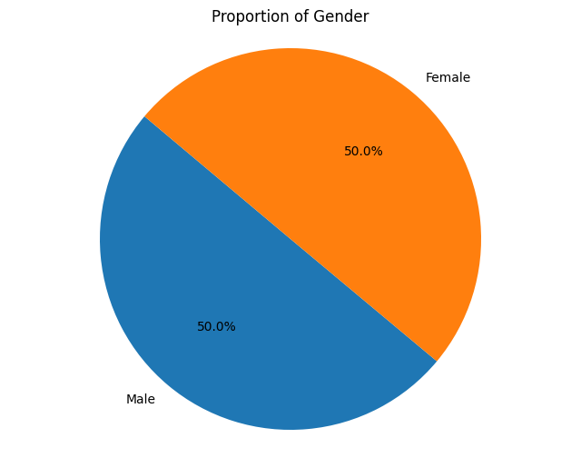

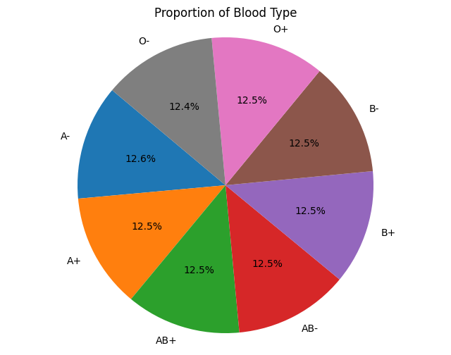

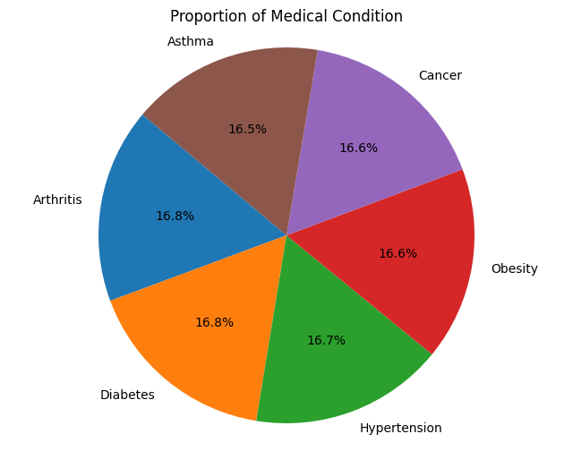

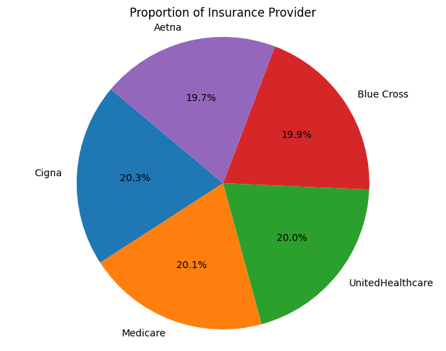

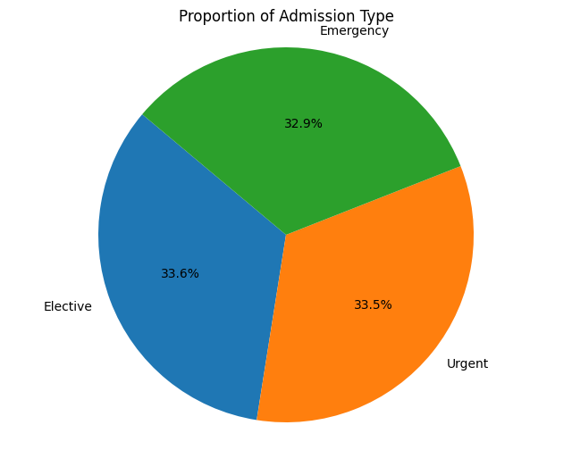

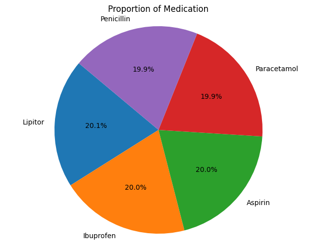

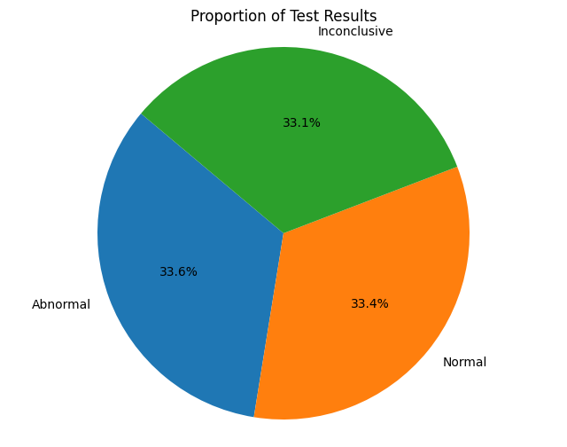

```python
# List of categorical variables to analyze
categorical_variables = [
    'Gender', 'Blood Type', 'Medical Condition',
    'Insurance Provider', 'Admission Type', 'Medication', 'Test Results'
]

# Function to plot pie chart for a categorical variable
def plot_pie_chart(df, column):
    data = df[column].value_counts()
    plt.figure(figsize=(8, 6))
    plt.pie(data, labels=data.index, autopct='%1.1f%%', startangle=140)
    plt.title(f'Proportion of {column}')
    plt.axis('equal')  # Equal aspect ratio ensures the pie is drawn as a circle.
    plt.show()

# Plot pie charts for each categorical variable
for var in categorical_variables:
    plot_pie_chart(health, var)
```

Given that all categories have frequencies that are as uniform as possible, it is very likely that whoever prepared the data made an intentional choice to distribute the values evenly. This uniform distribution across categories could have been done to avoid biases or to simulate a balanced dataset for analysis purposes.

Exploratory Data Analysis - Statistical Testing

Now we have a pretty good idea of what the dataset look like lets see if we could answer some interesting questions based on this dataset.

# Patient Demographics and Medical Conditions

## What is the relationship between age and medical conditions?

**Analysis of Variance (ANOVA)** is a statistical method used to compare the means of three or more groups to determine if there is a statistically significant difference between them. It tests the hypothesis that the means of different groups are equal by analyzing the variance within each group and the variance between the groups.

### How ANOVA Answers Our Research Question

Our research question aims to determine if there is a significant relationship between age and medical conditions. Specifically, we want to know if the mean age of patients differs across various medical conditions.

**Why ANOVA is Appropriate:**

- **Comparing Multiple Groups:** We have multiple medical conditions, each representing a group. ANOVA allows us to compare the mean ages across these groups simultaneously.
- **Statistical Significance:** ANOVA provides a p-value to determine if any observed differences in means are statistically significant. A low p-value (typically < 0.05) indicates that at least one group mean is significantly different from the others.
- **Variance Analysis:** By analyzing the variance within each medical condition group and the variance between the groups, ANOVA helps us understand if age differences are more pronounced within groups or between them.

### Interpretation

- **Significant Difference:** If the p-value from the ANOVA test is less than 0.05, it indicates that there is a statistically significant difference in the mean ages across different medical conditions. This means that age is related to the type of medical condition.
- **No Significant Difference:** If the p-value is greater than 0.05, it suggests that there is no significant difference in the mean ages, implying that age does not vary significantly across different medical conditions.

By using ANOVA, we can rigorously test our hypothesis and draw meaningful conclusions about the relationship between age and medical conditions, which can inform healthcare strategies and interventions.

```python
import scipy.stats as stats
import statsmodels.api as sm
from statsmodels.formula.api import ols
```

```python
# Perform ANOVA
anova_model = ols('Age ~ C(Q("Medical Condition"))', data=health).fit()
anova_table = sm.stats.anova_lm(anova_model, typ=2)

print(anova_table)
```

```
                                 sum_sq       df         F    PR(>F)
C(Q("Medical Condition"))  1.229039e+03      5.0  0.639677  0.669432
Residual                   2.132461e+07  55494.0       NaN       NaN
```

## Conclusion

Based on the ANOVA results, the analysis reveals the following key points:

- **F-Statistic (F)**: The F-statistic is 0.639677, which compares the variance explained by the medical conditions to the unexplained variance.
- **P-Value (PR(>F))**: The p-value is 0.669432, which is well above the conventional threshold of 0.05 for statistical significance.

### Summary

The p-value of 0.669432 indicates that there is no statistically significant difference in the mean age across different medical conditions. Therefore, we conclude that medical conditions do not significantly affect the patient age in this dataset.

## Is there a significant difference in the distribution of medical conditions between genders?

**Description of Pearson Chi-Square Test**

The Pearson Chi-Square Test is a statistical test used to determine if there is a significant association between two categorical variables. It compares the observed frequencies of occurrences in each category of a contingency table with the frequencies that would be expected if there were no association between the variables. The test statistic measures how far the observed frequencies deviate from the expected frequencies, and the p-value indicates whether this deviation is statistically significant.

**How the Pearson Chi-Square Test Applies to Our Research Question**

Our research question aims to determine if there is a significant difference in the distribution of medical conditions between genders. Specifically, we want to know if the occurrence of different medical conditions is associated with the patient's gender. Since both gender and medical conditions are categorical variables, the Pearson Chi-Square Test is appropriate for this analysis.

**Why Pearson Chi-Square Test is Appropriate:**

- **Categorical Data:** Both 'Gender' and 'Medical Condition' are categorical variables, making the Chi-Square Test suitable for assessing the association between them.
- **Contingency Table Analysis:** The test analyzes the frequencies in a contingency table, comparing the observed counts of each medical condition across genders to the counts expected if there were no association.
- **Statistical Significance:** The Chi-Square Test provides a p-value to determine if any observed differences in frequencies are statistically significant. A low p-value (typically < 0.05) indicates a significant association between the variables.

**Interpretation:**

- **Significant Association:** If the p-value from the Chi-Square Test is less than 0.05, it indicates a significant association between gender and medical condition. This means that the distribution of medical conditions varies significantly between males and females.
- **No Significant Association:** If the p-value is greater than 0.05, it suggests no significant association between gender and medical condition, implying that the distribution of medical conditions is similar across genders.

By using the Pearson Chi-Square Test, we can rigorously assess whether gender influences the distribution of medical conditions in our dataset, providing valuable insights for healthcare strategies and interventions.

```python
# Create a contingency table
contingency_table = pd.crosstab(health['Gender'], health['Medical Condition'])

# Perform the Chi-Square Test
chi2, p, dof, expected = stats.chi2_contingency(contingency_table)

print(f"Chi-Square Test Statistic: {chi2}")
print(f"P-Value: {p}")
```

```
Chi-Square Test Statistic: 1.2017873650693676
P-Value: 0.9447057765170073
```

## Conclusion

The p-value of 0.9447057765170073 is much higher than the conventional threshold of 0.05 for statistical significance. This indicates that there is no statistically significant relationship between gender and medical condition in the dataset. Therefore, we conclude that gender does not significantly affect the distribution of medical conditions.

## Analysis of Billing Amount Variation with Age and Duration of Stay Using Linear Regression

Linear regression is a statistical method used to model the relationship between a dependent variable and one or more independent variables. In this context, we are examining how the billing amount (dependent variable) varies with age and the duration of stay (independent variables). By fitting a linear regression model, we aim to determine if there is a significant relationship between these factors and the billing amount.

### What is Regression?

Regression analysis helps in understanding the relationship between variables. In linear regression, the goal is to fit a linear equation to observed data. The equation of the form:

$$ \text{Billing Amount} = \beta_0 + \beta_1 \cdot \text{Age} + \beta_2 \cdot \text{Duration of Stay} + \epsilon $$

where:

- $\beta_0$ is the intercept,
- $\beta_1$ and (\beta_2) are the coefficients for age and duration of stay respectively,
- $\epsilon$ is the error term.

### Why Does Regression Answer Our Research Question?

1. **Identify Relationship**: Regression allows us to identify whether there is a statistically significant relationship between age, duration of stay, and the billing amount.
2. **Quantify Effect**: It quantifies the effect of age and duration of stay on billing amount, providing a measure of how much billing amounts change with each unit increase in age or duration of stay.
3. **Predict Future Values**: The regression model can be used to predict future billing amounts based on age and duration of stay, aiding in planning and decision-making.
4. **Assess Significance**: By evaluating the significance of the coefficients, we can determine if the observed relationships are not due to random chance, thus giving us confidence in the findings.

Overall, linear regression is a powerful tool for exploring and understanding the factors that influence billing amounts, making it an appropriate method for addressing our research question.

```python
#regression example
X = health[['Age','Duration of Admission']]
X.insert(loc=0,column='Intercept',  value=np.ones(X.shape[0]) )
y = health['Billing Amount']

model = sm.OLS(y, X)
results = model.fit()
summary = results.summary()
print(summary)
```

```
                            OLS Regression Results
==============================================================================
Dep. Variable:         Billing Amount   R-squared:                       0.000
Model:                            OLS   Adj. R-squared:                  0.000
Method:                 Least Squares   F-statistic:                     1.269
Date:                Sat, 06 Jul 2024   Prob (F-statistic):              0.281
Time:                        09:36:47   Log-Likelihood:            -6.0943e+05
No. Observations:               55500   AIC:                         1.219e+06
Df Residuals:                   55497   BIC:                         1.219e+06
Df Model:                           2
Covariance Type:            nonrobust
=========================================================================================
                            coef    std err          t      P>|t|      [0.025      0.975]
-----------------------------------------------------------------------------------------
Intercept              2.582e+04    200.471    128.810      0.000    2.54e+04    2.62e+04
Age                      -2.7449      3.078     -0.892      0.372      -8.777       3.287
Duration of Admission    -9.1419      6.966     -1.312      0.189     -22.796       4.512
==============================================================================
Omnibus:                    45122.165   Durbin-Watson:                   1.985
Prob(Omnibus):                  0.000   Jarque-Bera (JB):             3278.336
Skew:                          -0.001   Prob(JB):                         0.00
Kurtosis:                       1.809   Cond. No.                         190.
==============================================================================

Notes:
[1] Standard Errors assume that the covariance matrix of the errors is correctly specified.
```

## Summary of OLS Regression Results

### Key Interpretations

1. **Intercept**: The intercept is 25,820 USD, indicating the baseline billing amount when age and duration of admission are zero. This value is statistically significant (p < 0.001).
2. **Age**: The coefficient for age is -2.7449, suggesting that each additional year of age decreases the billing amount by approximately 2.7449 USD. However, this effect is not statistically significant (p = 0.372).
3. **Duration of Admission**: The coefficient for duration of admission is -9.1419, indicating that each additional day of admission decreases the billing amount by approximately 9.1419 USD. This effect is also not statistically significant (p = 0.189).
4. **R-squared**: The R-squared value is 0.000, meaning the model does not explain any of the variability in billing amounts. This suggests that age and duration of admission are not good predictors of billing amount in this dataset.
5. **F-statistic**: The F-statistic is 1.269 with a p-value of 0.281, indicating that the overall model is not statistically significant.

### Conclusion

The regression analysis shows that neither age nor duration of admission significantly affects the billing amount. The very low R-squared value indicates that these variables do not explain the variability in billing amounts. Further analysis with additional variables or different modeling techniques may be necessary to better understand the factors affecting billing amounts.

## Analysis of the Effect of Medical Condition on Billing Amount Using ANOVA

### Why Use ANOVA to Answer the Research Question?

1. **Comparative Analysis**: ANOVA allows us to compare the billing amounts across multiple medical conditions simultaneously. It tests whether the means of billing amounts for different medical conditions are significantly different from each other.
2. **Assess Variation**: It helps in assessing the variation in billing amounts attributed to different medical conditions, isolating this effect from the overall variation in the dataset.
3. **Statistical Significance**: ANOVA provides a p-value that indicates whether the observed differences in billing amounts across medical conditions are statistically significant. A low p-value suggests that at least one medical condition has a different mean billing amount compared to others.
4. **Quantify Impact**: The results from ANOVA quantify the impact of medical condition on billing amounts, aiding in understanding how much of the variation in billing costs can be explained by the medical conditions.

By utilizing ANOVA, we can robustly determine if medical conditions significantly influence billing amounts, thereby answering our research question with statistical evidence.

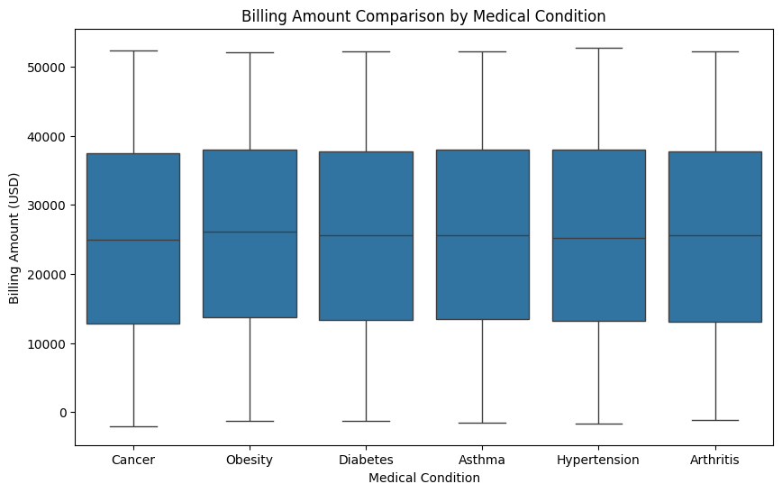

```python
# Create the box plot
plt.figure(figsize=(10, 6))
sns.boxplot(x='Medical Condition', y='Billing Amount', data=health)

# Customize the plot
plt.title('Billing Amount Comparison by Medical Condition')
plt.xlabel('Medical Condition')
plt.ylabel('Billing Amount (USD)')

# Show the plot
plt.show()
```

```python
# Perform ANOVA
anova_model = ols('Q("Billing Amount") ~ C(Q("Medical Condition"))', data=health).fit()
anova_table = sm.stats.anova_lm(anova_model, typ=2)

print(anova_table)
```

```
                                 sum_sq       df         F    PR(>F)
C(Q("Medical Condition"))  2.180213e+09      5.0  2.159222  0.055592
Residual                   1.120670e+13  55494.0       NaN       NaN
```

## Conclusion

Based on the ANOVA results, the analysis reveals the following key points:

- **F-Statistic (F)**: The F-statistic is 2.159222, which compares the variance explained by the medical conditions to the unexplained variance.
- **P-Value (PR(>F))**: The p-value is 0.055592, which is slightly above the conventional threshold of 0.05 for statistical significance.

### Summary

The p-value of 0.055592 indicates that there is no statistically significant difference in the mean billing amount across different medical conditions at the 5% significance level. Therefore, we conclude that medical conditions do not significantly affect the billing amounts in this dataset.